# Risk Factor Analysis

## Outcome Variable

**Outcome Variable:** whz

## Predictor Variables

**Intervention Variable:** impsan

**Adjustment Set:**

unadjusted

## Stratifying Variables

The analysis was stratified on these variable(s):

- agecat
- studyid
- country

## Data Summary

| agecat | studyid | country | impsan | n_cell | n |
| --- | --- | --- | --- | --- | --- |
| Birth | ki0047075b-MAL-ED | BANGLADESH | 1 | 186 | 222 |
| Birth | ki0047075b-MAL-ED | BANGLADESH | 0 | 36 | 222 |
| Birth | ki0047075b-MAL-ED | BRAZIL | 1 | 163 | 167 |
| Birth | ki0047075b-MAL-ED | BRAZIL | 0 | 4 | 167 |
| Birth | ki0047075b-MAL-ED | INDIA | 1 | 90 | 188 |
| Birth | ki0047075b-MAL-ED | INDIA | 0 | 98 | 188 |
| Birth | ki0047075b-MAL-ED | NEPAL | 1 | 165 | 166 |
| Birth | ki0047075b-MAL-ED | NEPAL | 0 | 1 | 166 |
| Birth | ki0047075b-MAL-ED | PERU | 1 | 60 | 243 |
| Birth | ki0047075b-MAL-ED | PERU | 0 | 183 | 243 |
| Birth | ki0047075b-MAL-ED | SOUTH AFRICA | 1 | 2 | 211 |
| Birth | ki0047075b-MAL-ED | SOUTH AFRICA | 0 | 209 | 211 |
| Birth | ki0047075b-MAL-ED | TANZANIA, UNITED REPUBLIC OF | 1 | 0 | 109 |
| Birth | ki0047075b-MAL-ED | TANZANIA, UNITED REPUBLIC OF | 0 | 109 | 109 |
| Birth | ki1017093-NIH-Birth | BANGLADESH | 1 | 9 | 28 |
| Birth | ki1017093-NIH-Birth | BANGLADESH | 0 | 19 | 28 |
| Birth | ki1017093c-NIH-Crypto | BANGLADESH | 1 | 21 | 23 |
| Birth | ki1017093c-NIH-Crypto | BANGLADESH | 0 | 2 | 23 |
| Birth | ki1114097-CONTENT | PERU | 1 | 1 | 2 |
| Birth | ki1114097-CONTENT | PERU | 0 | 1 | 2 |
| Birth | ki1135781-COHORTS | GUATEMALA | 1 | 43 | 449 |
| Birth | ki1135781-COHORTS | GUATEMALA | 0 | 406 | 449 |
| Birth | ki1135781-COHORTS | INDIA | 1 | 1685 | 4461 |
| Birth | ki1135781-COHORTS | INDIA | 0 | 2776 | 4461 |
| Birth | ki1135781-COHORTS | PHILIPPINES | 1 | 177 | 1126 |
| Birth | ki1135781-COHORTS | PHILIPPINES | 0 | 949 | 1126 |
| Birth | kiGH5241-JiVitA-3 | BANGLADESH | 1 | 10724 | 15689 |
| Birth | kiGH5241-JiVitA-3 | BANGLADESH | 0 | 4965 | 15689 |
| Birth | kiGH5241-JiVitA-4 | BANGLADESH | 1 | 503 | 683 |
| Birth | kiGH5241-JiVitA-4 | BANGLADESH | 0 | 180 | 683 |

[output cut: 68 more lines]

The following strata were considered:

- agecat: 24 months, studyid: ki0047075b-MAL-ED, country: BANGLADESH
- agecat: 24 months, studyid: ki0047075b-MAL-ED, country: BRAZIL
- agecat: 24 months, studyid: ki0047075b-MAL-ED, country: INDIA
- agecat: 24 months, studyid: ki0047075b-MAL-ED, country: NEPAL
- agecat: 24 months, studyid: ki0047075b-MAL-ED, country: PERU
- agecat: 24 months, studyid: ki0047075b-MAL-ED, country: SOUTH AFRICA
- agecat: 24 months, studyid: ki0047075b-MAL-ED, country: TANZANIA, UNITED REPUBLIC OF
- agecat: 24 months, studyid: ki1017093-NIH-Birth, country: BANGLADESH
- agecat: 24 months, studyid: ki1017093b-PROVIDE, country: BANGLADESH
- agecat: 24 months, studyid: ki1017093c-NIH-Crypto, country: BANGLADESH
- agecat: 24 months, studyid: ki1114097-CONTENT, country: PERU
- agecat: 24 months, studyid: ki1135781-COHORTS, country: GUATEMALA
- agecat: 24 months, studyid: ki1135781-COHORTS, country: INDIA
- agecat: 24 months, studyid: ki1135781-COHORTS, country: PHILIPPINES
- agecat: 24 months, studyid: ki1148112-LCNI-5, country: MALAWI
- agecat: 24 months, studyid: kiGH5241-JiVitA-3, country: BANGLADESH
- agecat: 24 months, studyid: kiGH5241-JiVitA-4, country: BANGLADESH
- agecat: 6 months, studyid: ki0047075b-MAL-ED, country: BANGLADESH
- agecat: 6 months, studyid: ki0047075b-MAL-ED, country: BRAZIL
- agecat: 6 months, studyid: ki0047075b-MAL-ED, country: INDIA
- agecat: 6 months, studyid: ki0047075b-MAL-ED, country: NEPAL
- agecat: 6 months, studyid: ki0047075b-MAL-ED, country: PERU
- agecat: 6 months, studyid: ki0047075b-MAL-ED, country: SOUTH AFRICA
- agecat: 6 months, studyid: ki0047075b-MAL-ED, country: TANZANIA, UNITED REPUBLIC OF
- agecat: 6 months, studyid: ki1017093-NIH-Birth, country: BANGLADESH
- agecat: 6 months, studyid: ki1017093b-PROVIDE, country: BANGLADESH
- agecat: 6 months, studyid: ki1017093c-NIH-Crypto, country: BANGLADESH
- agecat: 6 months, studyid: ki1114097-CONTENT, country: PERU
- agecat: 6 months, studyid: ki1135781-COHORTS, country: GUATEMALA
- agecat: 6 months, studyid: ki1135781-COHORTS, country: INDIA
- agecat: 6 months, studyid: ki1135781-COHORTS, country: PHILIPPINES
- agecat: 6 months, studyid: ki1148112-LCNI-5, country: MALAWI
- agecat: 6 months, studyid: kiGH5241-JiVitA-3, country: BANGLADESH
- agecat: 6 months, studyid: kiGH5241-JiVitA-4, country: BANGLADESH
- agecat: Birth, studyid: ki0047075b-MAL-ED, country: BANGLADESH
- agecat: Birth, studyid: ki0047075b-MAL-ED, country: BRAZIL
- agecat: Birth, studyid: ki0047075b-MAL-ED, country: INDIA
- agecat: Birth, studyid: ki0047075b-MAL-ED, country: NEPAL
- agecat: Birth, studyid: ki0047075b-MAL-ED, country: PERU
- agecat: Birth, studyid: ki0047075b-MAL-ED, country: SOUTH AFRICA
- agecat: Birth, studyid: ki0047075b-MAL-ED, country: TANZANIA, UNITED REPUBLIC OF
- agecat: Birth, studyid: ki1017093-NIH-Birth, country: BANGLADESH
- agecat: Birth, studyid: ki1017093c-NIH-Crypto, country: BANGLADESH
- agecat: Birth, studyid: ki1114097-CONTENT, country: PERU
- agecat: Birth, studyid: ki1135781-COHORTS, country: GUATEMALA
- agecat: Birth, studyid: ki1135781-COHORTS, country: INDIA
- agecat: Birth, studyid: ki1135781-COHORTS, country: PHILIPPINES
- agecat: Birth, studyid: kiGH5241-JiVitA-3, country: BANGLADESH
- agecat: Birth, studyid: kiGH5241-JiVitA-4, country: BANGLADESH

### Dropped Strata

Some strata were dropped due to rare outcomes:

- agecat: Birth, studyid: ki0047075b-MAL-ED, country: BRAZIL
- agecat: Birth, studyid: ki0047075b-MAL-ED, country: NEPAL
- agecat: Birth, studyid: ki0047075b-MAL-ED, country: SOUTH AFRICA
- agecat: Birth, studyid: ki0047075b-MAL-ED, country: TANZANIA, UNITED REPUBLIC OF
- agecat: Birth, studyid: ki1017093c-NIH-Crypto, country: BANGLADESH
- agecat: Birth, studyid: ki1114097-CONTENT, country: PERU
- agecat: 6 months, studyid: ki0047075b-MAL-ED, country: BRAZIL
- agecat: 6 months, studyid: ki0047075b-MAL-ED, country: NEPAL
- agecat: 6 months, studyid: ki0047075b-MAL-ED, country: SOUTH AFRICA
- agecat: 6 months, studyid: ki0047075b-MAL-ED, country: TANZANIA, UNITED REPUBLIC OF
- agecat: 6 months, studyid: ki1148112-LCNI-5, country: MALAWI
- agecat: 24 months, studyid: ki0047075b-MAL-ED, country: BRAZIL
- agecat: 24 months, studyid: ki0047075b-MAL-ED, country: NEPAL
- agecat: 24 months, studyid: ki0047075b-MAL-ED, country: SOUTH AFRICA
- agecat: 24 months, studyid: ki0047075b-MAL-ED, country: TANZANIA, UNITED REPUBLIC OF
- agecat: 24 months, studyid: ki1148112-LCNI-5, country: MALAWI

## Methods Detail

We’re interested in the causal parameters $E[Y_a]$ for all values of $a \in \mathcal{A}$. These parameters represent the mean outcome if, possibly contrary to fact, we intervened to set all units to have $A=a$. Under the randomization and positivity assumptions, these are identified by the statistical parameters $\psi_a=E_W[E_{Y|A,W}(Y|A=a,W)]$. In addition, we’re interested in the mean of $Y$, $E[Y]$ under no intervention (the observed mean). We will estimate these parameters by using SuperLearner to fit the relevant likelihood factors – $E_{Y|A,W}(Y|A=a,W)$ and $p(A=a|W)$, and then updating our likelihood fit using a joint TMLE.

For unadjusted analyses ($W=\{\}$), initial likelihoods were estimated using Lrnr_glm to estimate the simple $E(Y|A)$ and Lrnr_mean to estimate $p(A)$. For adjusted analyses, a small library containing Lrnr_glmnet, Lrnr_xgboost, and Lrnr_mean was used.

# Results Detail

## Results Plots

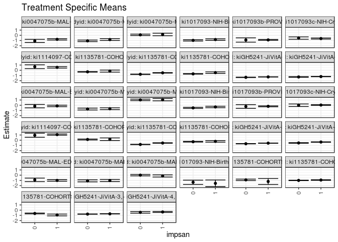

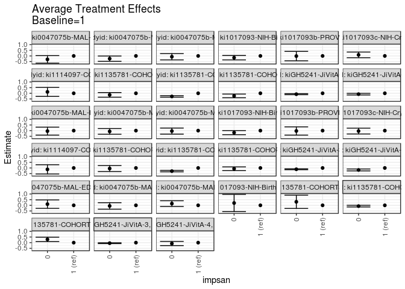

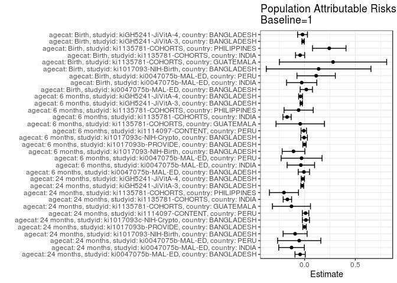

## Results Table

### Parameter: TSM

| agecat | studyid | country | intervention_level | baseline_level | estimate | ci_lower | ci_upper |
| --- | --- | --- | --- | --- | --- | --- | --- |
| Birth | ki0047075b-MAL-ED | BANGLADESH | 1 | NA | -1.0072043 | -1.1619389 | -0.8524697 |
| Birth | ki0047075b-MAL-ED | BANGLADESH | 0 | NA | -0.9025000 | -1.2410835 | -0.5639165 |
| Birth | ki0047075b-MAL-ED | INDIA | 1 | NA | -1.0248889 | -1.2321717 | -0.8176061 |
| Birth | ki0047075b-MAL-ED | INDIA | 0 | NA | -1.0801020 | -1.2770422 | -0.8831619 |
| Birth | ki0047075b-MAL-ED | PERU | 1 | NA | -0.1453333 | -0.3534429 | 0.0627762 |
| Birth | ki0047075b-MAL-ED | PERU | 0 | NA | 0.0057377 | -0.1348876 | 0.1463630 |
| Birth | ki1017093-NIH-Birth | BANGLADESH | 1 | NA | -1.5622222 | -2.2052846 | -0.9191599 |
| Birth | ki1017093-NIH-Birth | BANGLADESH | 0 | NA | -1.3584211 | -1.7618042 | -0.9550379 |
| Birth | ki1135781-COHORTS | GUATEMALA | 1 | NA | -1.2097674 | -1.7770248 | -0.6425100 |
| Birth | ki1135781-COHORTS | GUATEMALA | 0 | NA | -0.8997537 | -1.0430165 | -0.7564909 |
| Birth | ki1135781-COHORTS | INDIA | 1 | NA | -0.9326588 | -0.9904202 | -0.8748973 |
| Birth | ki1135781-COHORTS | INDIA | 0 | NA | -1.0041931 | -1.0477639 | -0.9606223 |
| Birth | ki1135781-COHORTS | PHILIPPINES | 1 | NA | -0.9272881 | -1.1054546 | -0.7491217 |
| Birth | ki1135781-COHORTS | PHILIPPINES | 0 | NA | -0.6387460 | -0.7199134 | -0.5575787 |
| Birth | kiGH5241-JiVitA-3 | BANGLADESH | 1 | NA | -0.7091421 | -0.7329606 | -0.6853236 |
| Birth | kiGH5241-JiVitA-3 | BANGLADESH | 0 | NA | -0.7557482 | -0.7857470 | -0.7257495 |
| Birth | kiGH5241-JiVitA-4 | BANGLADESH | 1 | NA | -0.3478529 | -0.4422517 | -0.2534541 |
| Birth | kiGH5241-JiVitA-4 | BANGLADESH | 0 | NA | -0.4255000 | -0.5823269 | -0.2686731 |
| 6 months | ki0047075b-MAL-ED | BANGLADESH | 1 | NA | -0.1285355 | -0.2696132 | 0.0125423 |
| 6 months | ki0047075b-MAL-ED | BANGLADESH | 0 | NA | -0.1722807 | -0.4957385 | 0.1511770 |
| 6 months | ki0047075b-MAL-ED | INDIA | 1 | NA | -0.6635185 | -0.8416457 | -0.4853913 |
| 6 months | ki0047075b-MAL-ED | INDIA | 0 | NA | -0.7323733 | -0.9106129 | -0.5541337 |
| 6 months | ki0047075b-MAL-ED | PERU | 1 | NA | 1.0673846 | 0.8427808 | 1.2919884 |
| 6 months | ki0047075b-MAL-ED | PERU | 0 | NA | 1.0278535 | 0.8814424 | 1.1742647 |
| 6 months | ki1017093-NIH-Birth | BANGLADESH | 1 | NA | -0.3295000 | -0.4693882 | -0.1896118 |
| 6 months | ki1017093-NIH-Birth | BANGLADESH | 0 | NA | -0.5066717 | -0.6213040 | -0.3920394 |
| 6 months | ki1017093b-PROVIDE | BANGLADESH | 1 | NA | -0.2066185 | -0.2937378 | -0.1194992 |
| 6 months | ki1017093b-PROVIDE | BANGLADESH | 0 | NA | -0.2378846 | -0.5919374 | 0.1161682 |
| 6 months | ki1017093c-NIH-Crypto | BANGLADESH | 1 | NA | 0.0387398 | -0.0450978 | 0.1225775 |
| 6 months | ki1017093c-NIH-Crypto | BANGLADESH | 0 | NA | -0.0012921 | -0.2470796 | 0.2444953 |
| 6 months | ki1114097-CONTENT | PERU | 1 | NA | 1.0764793 | 0.9544844 | 1.1984742 |
| 6 months | ki1114097-CONTENT | PERU | 0 | NA | 0.9528929 | 0.5636843 | 1.3421014 |
| 6 months | ki1135781-COHORTS | GUATEMALA | 1 | NA | 0.1889552 | -0.0603936 | 0.4383041 |
| 6 months | ki1135781-COHORTS | GUATEMALA | 0 | NA | 0.1409645 | 0.0484498 | 0.2334792 |
| 6 months | ki1135781-COHORTS | INDIA | 1 | NA | -0.5374029 | -0.5878113 | -0.4869945 |
| 6 months | ki1135781-COHORTS | INDIA | 0 | NA | -0.8159060 | -0.8574428 | -0.7743692 |
| 6 months | ki1135781-COHORTS | PHILIPPINES | 1 | NA | -0.2241958 | -0.3741126 | -0.0742790 |
| 6 months | ki1135781-COHORTS | PHILIPPINES | 0 | NA | -0.2919787 | -0.3621714 | -0.2217860 |
| 6 months | kiGH5241-JiVitA-3 | BANGLADESH | 1 | NA | -0.5604582 | -0.5833363 | -0.5375801 |
| 6 months | kiGH5241-JiVitA-3 | BANGLADESH | 0 | NA | -0.6756957 | -0.7081148 | -0.6432765 |
| 6 months | kiGH5241-JiVitA-4 | BANGLADESH | 1 | NA | -0.3504794 | -0.3920046 | -0.3089541 |
| 6 months | kiGH5241-JiVitA-4 | BANGLADESH | 0 | NA | -0.5257182 | -0.5991376 | -0.4522988 |
| 24 months | ki0047075b-MAL-ED | BANGLADESH | 1 | NA | -0.7765193 | -0.9085885 | -0.6444502 |
| 24 months | ki0047075b-MAL-ED | BANGLADESH | 0 | NA | -1.0795161 | -1.3842300 | -0.7748023 |
| 24 months | ki0047075b-MAL-ED | INDIA | 1 | NA | -0.8208173 | -1.0001420 | -0.6414926 |
| 24 months | ki0047075b-MAL-ED | INDIA | 0 | NA | -1.0604132 | -1.2087690 | -0.9120575 |
| 24 months | ki0047075b-MAL-ED | PERU | 1 | NA | 0.1595745 | -0.0838723 | 0.4030212 |
| 24 months | ki0047075b-MAL-ED | PERU | 0 | NA | 0.0896644 | -0.0498537 | 0.2291826 |
| 24 months | ki1017093-NIH-Birth | BANGLADESH | 1 | NA | -0.8179853 | -0.9643157 | -0.6716549 |
| 24 months | ki1017093-NIH-Birth | BANGLADESH | 0 | NA | -0.9732494 | -1.1034383 | -0.8430604 |
| 24 months | ki1017093b-PROVIDE | BANGLADESH | 1 | NA | -0.8890778 | -0.9738656 | -0.8042899 |
| 24 months | ki1017093b-PROVIDE | BANGLADESH | 0 | NA | -0.9020833 | -1.3089908 | -0.4951759 |
| 24 months | ki1017093c-NIH-Crypto | BANGLADESH | 1 | NA | -0.6247113 | -0.7300064 | -0.5194162 |
| 24 months | ki1017093c-NIH-Crypto | BANGLADESH | 0 | NA | -0.5302857 | -0.7567763 | -0.3037952 |
| 24 months | ki1114097-CONTENT | PERU | 1 | NA | 0.5570861 | 0.4122926 | 0.7018796 |
| 24 months | ki1114097-CONTENT | PERU | 0 | NA | 0.6800000 | 0.3108002 | 1.0491998 |
| 24 months | ki1135781-COHORTS | GUATEMALA | 1 | NA | -0.1564935 | -0.3517559 | 0.0387688 |
| 24 months | ki1135781-COHORTS | GUATEMALA | 0 | NA | -0.2982809 | -0.3611991 | -0.2353627 |
| 24 months | ki1135781-COHORTS | INDIA | 1 | NA | -0.4907687 | -0.5439126 | -0.4376248 |
| 24 months | ki1135781-COHORTS | INDIA | 0 | NA | -0.7698941 | -0.8116988 | -0.7280895 |
| 24 months | ki1135781-COHORTS | PHILIPPINES | 1 | NA | -0.4527419 | -0.6040816 | -0.3014023 |
| 24 months | ki1135781-COHORTS | PHILIPPINES | 0 | NA | -0.6854776 | -0.7479453 | -0.6230098 |
| 24 months | kiGH5241-JiVitA-3 | BANGLADESH | 1 | NA | -1.2737666 | -1.3012095 | -1.2463238 |
| 24 months | kiGH5241-JiVitA-3 | BANGLADESH | 0 | NA | -1.3535128 | -1.3936262 | -1.3133993 |
| 24 months | kiGH5241-JiVitA-4 | BANGLADESH | 1 | NA | -1.2060120 | -1.2413492 | -1.1706748 |
| 24 months | kiGH5241-JiVitA-4 | BANGLADESH | 0 | NA | -1.2826818 | -1.3465837 | -1.2187799 |

### Parameter: E(Y)

| agecat | studyid | country | intervention_level | baseline_level | estimate | ci_lower | ci_upper |
| --- | --- | --- | --- | --- | --- | --- | --- |
| Birth | ki0047075b-MAL-ED | BANGLADESH | NA | NA | -0.9902252 | -1.1311070 | -0.8493435 |
| Birth | ki0047075b-MAL-ED | INDIA | NA | NA | -1.0536702 | -1.1965043 | -0.9108361 |
| Birth | ki0047075b-MAL-ED | PERU | NA | NA | -0.0315638 | -0.1495606 | 0.0864330 |
| Birth | ki1017093-NIH-Birth | BANGLADESH | NA | NA | -1.4239286 | -1.7688028 | -1.0790544 |
| Birth | ki1135781-COHORTS | GUATEMALA | NA | NA | -0.9294432 | -1.0701697 | -0.7887168 |
| Birth | ki1135781-COHORTS | INDIA | NA | NA | -0.9771733 | -1.0119896 | -0.9423570 |
| Birth | ki1135781-COHORTS | PHILIPPINES | NA | NA | -0.6841030 | -0.7582767 | -0.6099293 |
| Birth | kiGH5241-JiVitA-3 | BANGLADESH | NA | NA | -0.7238913 | -0.7437437 | -0.7040388 |
| Birth | kiGH5241-JiVitA-4 | BANGLADESH | NA | NA | -0.3683163 | -0.4490504 | -0.2875821 |
| 6 months | ki0047075b-MAL-ED | BANGLADESH | NA | NA | -0.1354618 | -0.2647919 | -0.0061317 |
| 6 months | ki0047075b-MAL-ED | INDIA | NA | NA | -0.7004578 | -0.8268704 | -0.5740452 |
| 6 months | ki0047075b-MAL-ED | PERU | NA | NA | 1.0376236 | 0.9141918 | 1.1610554 |
| 6 months | ki1017093-NIH-Birth | BANGLADESH | NA | NA | -0.4389101 | -0.5279432 | -0.3498771 |
| 6 months | ki1017093b-PROVIDE | BANGLADESH | NA | NA | -0.2080201 | -0.2927357 | -0.1233045 |
| 6 months | ki1017093c-NIH-Crypto | BANGLADESH | NA | NA | 0.0336790 | -0.0458848 | 0.1132428 |
| 6 months | ki1114097-CONTENT | PERU | NA | NA | 1.0684318 | 0.9515274 | 1.1853362 |
| 6 months | ki1135781-COHORTS | GUATEMALA | NA | NA | 0.1458511 | 0.0589571 | 0.2327450 |
| 6 months | ki1135781-COHORTS | INDIA | NA | NA | -0.7104855 | -0.7428053 | -0.6781657 |
| 6 months | ki1135781-COHORTS | PHILIPPINES | NA | NA | -0.2830286 | -0.3471028 | -0.2189545 |
| 6 months | kiGH5241-JiVitA-3 | BANGLADESH | NA | NA | -0.5931476 | -0.6127125 | -0.5735828 |
| 6 months | kiGH5241-JiVitA-4 | BANGLADESH | NA | NA | -0.3901595 | -0.4274150 | -0.3529041 |
| 24 months | ki0047075b-MAL-ED | BANGLADESH | NA | NA | -0.8208255 | -0.9429246 | -0.6987264 |
| 24 months | ki0047075b-MAL-ED | INDIA | NA | NA | -0.9496667 | -1.0657716 | -0.8335618 |
| 24 months | ki0047075b-MAL-ED | PERU | NA | NA | 0.1064286 | -0.0147106 | 0.2275677 |
| 24 months | ki1017093-NIH-Birth | BANGLADESH | NA | NA | -0.9115790 | -1.0095022 | -0.8136559 |
| 24 months | ki1017093b-PROVIDE | BANGLADESH | NA | NA | -0.8896187 | -0.9726240 | -0.8066134 |
| 24 months | ki1017093c-NIH-Crypto | BANGLADESH | NA | NA | -0.6115706 | -0.7075788 | -0.5155624 |
| 24 months | ki1114097-CONTENT | PERU | NA | NA | 0.5668293 | 0.4302437 | 0.7034148 |
| 24 months | ki1135781-COHORTS | GUATEMALA | NA | NA | -0.2861905 | -0.3461594 | -0.2262216 |
| 24 months | ki1135781-COHORTS | INDIA | NA | NA | -0.6606874 | -0.6938402 | -0.6275347 |
| 24 months | ki1135781-COHORTS | PHILIPPINES | NA | NA | -0.6564149 | -0.7144543 | -0.5983756 |
| 24 months | kiGH5241-JiVitA-3 | BANGLADESH | NA | NA | -1.2970418 | -1.3203361 | -1.2737475 |
| 24 months | kiGH5241-JiVitA-4 | BANGLADESH | NA | NA | -1.2231776 | -1.2550332 | -1.1913220 |

### Parameter: ATE

| agecat | studyid | country | intervention_level | baseline_level | estimate | ci_lower | ci_upper |
| --- | --- | --- | --- | --- | --- | --- | --- |
| Birth | ki0047075b-MAL-ED | BANGLADESH | 1 | 1 | 0.0000000 | 0.0000000 | 0.0000000 |
| Birth | ki0047075b-MAL-ED | BANGLADESH | 0 | 1 | 0.1047043 | -0.2675611 | 0.4769697 |
| Birth | ki0047075b-MAL-ED | INDIA | 1 | 1 | 0.0000000 | 0.0000000 | 0.0000000 |
| Birth | ki0047075b-MAL-ED | INDIA | 0 | 1 | -0.0552132 | -0.3411355 | 0.2307092 |
| Birth | ki0047075b-MAL-ED | PERU | 1 | 1 | 0.0000000 | 0.0000000 | 0.0000000 |
| Birth | ki0047075b-MAL-ED | PERU | 0 | 1 | 0.1510710 | -0.1000964 | 0.4022385 |
| Birth | ki1017093-NIH-Birth | BANGLADESH | 1 | 1 | 0.0000000 | 0.0000000 | 0.0000000 |
| Birth | ki1017093-NIH-Birth | BANGLADESH | 0 | 1 | 0.2038012 | -0.5553083 | 0.9629106 |
| Birth | ki1135781-COHORTS | GUATEMALA | 1 | 1 | 0.0000000 | 0.0000000 | 0.0000000 |
| Birth | ki1135781-COHORTS | GUATEMALA | 0 | 1 | 0.3100137 | -0.2750548 | 0.8950823 |
| Birth | ki1135781-COHORTS | INDIA | 1 | 1 | 0.0000000 | 0.0000000 | 0.0000000 |
| Birth | ki1135781-COHORTS | INDIA | 0 | 1 | -0.0715343 | -0.1438862 | 0.0008176 |
| Birth | ki1135781-COHORTS | PHILIPPINES | 1 | 1 | 0.0000000 | 0.0000000 | 0.0000000 |
| Birth | ki1135781-COHORTS | PHILIPPINES | 0 | 1 | 0.2885421 | 0.0927580 | 0.4843262 |
| Birth | kiGH5241-JiVitA-3 | BANGLADESH | 1 | 1 | 0.0000000 | 0.0000000 | 0.0000000 |
| Birth | kiGH5241-JiVitA-3 | BANGLADESH | 0 | 1 | -0.0466061 | -0.0824758 | -0.0107364 |
| Birth | kiGH5241-JiVitA-4 | BANGLADESH | 1 | 1 | 0.0000000 | 0.0000000 | 0.0000000 |
| Birth | kiGH5241-JiVitA-4 | BANGLADESH | 0 | 1 | -0.0776471 | -0.2613530 | 0.1060587 |
| 6 months | ki0047075b-MAL-ED | BANGLADESH | 1 | 1 | 0.0000000 | 0.0000000 | 0.0000000 |
| 6 months | ki0047075b-MAL-ED | BANGLADESH | 0 | 1 | -0.0437452 | -0.3966303 | 0.3091398 |
| 6 months | ki0047075b-MAL-ED | INDIA | 1 | 1 | 0.0000000 | 0.0000000 | 0.0000000 |
| 6 months | ki0047075b-MAL-ED | INDIA | 0 | 1 | -0.0688548 | -0.3208442 | 0.1831346 |
| 6 months | ki0047075b-MAL-ED | PERU | 1 | 1 | 0.0000000 | 0.0000000 | 0.0000000 |
| 6 months | ki0047075b-MAL-ED | PERU | 0 | 1 | -0.0395311 | -0.3076413 | 0.2285791 |
| 6 months | ki1017093-NIH-Birth | BANGLADESH | 1 | 1 | 0.0000000 | 0.0000000 | 0.0000000 |
| 6 months | ki1017093-NIH-Birth | BANGLADESH | 0 | 1 | -0.1771717 | -0.3580288 | 0.0036854 |
| 6 months | ki1017093b-PROVIDE | BANGLADESH | 1 | 1 | 0.0000000 | 0.0000000 | 0.0000000 |
| 6 months | ki1017093b-PROVIDE | BANGLADESH | 0 | 1 | -0.0312661 | -0.3958798 | 0.3333476 |
| 6 months | ki1017093c-NIH-Crypto | BANGLADESH | 1 | 1 | 0.0000000 | 0.0000000 | 0.0000000 |
| 6 months | ki1017093c-NIH-Crypto | BANGLADESH | 0 | 1 | -0.0400320 | -0.2997245 | 0.2196606 |
| 6 months | ki1114097-CONTENT | PERU | 1 | 1 | 0.0000000 | 0.0000000 | 0.0000000 |
| 6 months | ki1114097-CONTENT | PERU | 0 | 1 | -0.1235864 | -0.5314664 | 0.2842935 |
| 6 months | ki1135781-COHORTS | GUATEMALA | 1 | 1 | 0.0000000 | 0.0000000 | 0.0000000 |
| 6 months | ki1135781-COHORTS | GUATEMALA | 0 | 1 | -0.0479908 | -0.3139491 | 0.2179675 |
| 6 months | ki1135781-COHORTS | INDIA | 1 | 1 | 0.0000000 | 0.0000000 | 0.0000000 |
| 6 months | ki1135781-COHORTS | INDIA | 0 | 1 | -0.2785031 | -0.3438202 | -0.2131861 |
| 6 months | ki1135781-COHORTS | PHILIPPINES | 1 | 1 | 0.0000000 | 0.0000000 | 0.0000000 |
| 6 months | ki1135781-COHORTS | PHILIPPINES | 0 | 1 | -0.0677829 | -0.2333186 | 0.0977527 |
| 6 months | kiGH5241-JiVitA-3 | BANGLADESH | 1 | 1 | 0.0000000 | 0.0000000 | 0.0000000 |
| 6 months | kiGH5241-JiVitA-3 | BANGLADESH | 0 | 1 | -0.1152375 | -0.1530712 | -0.0774038 |
| 6 months | kiGH5241-JiVitA-4 | BANGLADESH | 1 | 1 | 0.0000000 | 0.0000000 | 0.0000000 |
| 6 months | kiGH5241-JiVitA-4 | BANGLADESH | 0 | 1 | -0.1752388 | -0.2581557 | -0.0923219 |
| 24 months | ki0047075b-MAL-ED | BANGLADESH | 1 | 1 | 0.0000000 | 0.0000000 | 0.0000000 |
| 24 months | ki0047075b-MAL-ED | BANGLADESH | 0 | 1 | -0.3029968 | -0.6351004 | 0.0291068 |
| 24 months | ki0047075b-MAL-ED | INDIA | 1 | 1 | 0.0000000 | 0.0000000 | 0.0000000 |
| 24 months | ki0047075b-MAL-ED | INDIA | 0 | 1 | -0.2395959 | -0.4723335 | -0.0068584 |
| 24 months | ki0047075b-MAL-ED | PERU | 1 | 1 | 0.0000000 | 0.0000000 | 0.0000000 |
| 24 months | ki0047075b-MAL-ED | PERU | 0 | 1 | -0.0699100 | -0.3505016 | 0.2106815 |
| 24 months | ki1017093-NIH-Birth | BANGLADESH | 1 | 1 | 0.0000000 | 0.0000000 | 0.0000000 |
| 24 months | ki1017093-NIH-Birth | BANGLADESH | 0 | 1 | -0.1552641 | -0.3511256 | 0.0405975 |
| 24 months | ki1017093b-PROVIDE | BANGLADESH | 1 | 1 | 0.0000000 | 0.0000000 | 0.0000000 |
| 24 months | ki1017093b-PROVIDE | BANGLADESH | 0 | 1 | -0.0130056 | -0.4286529 | 0.4026417 |
| 24 months | ki1017093c-NIH-Crypto | BANGLADESH | 1 | 1 | 0.0000000 | 0.0000000 | 0.0000000 |
| 24 months | ki1017093c-NIH-Crypto | BANGLADESH | 0 | 1 | 0.0944256 | -0.1553443 | 0.3441955 |
| 24 months | ki1114097-CONTENT | PERU | 1 | 1 | 0.0000000 | 0.0000000 | 0.0000000 |
| 24 months | ki1114097-CONTENT | PERU | 0 | 1 | 0.1229139 | -0.2736635 | 0.5194913 |
| 24 months | ki1135781-COHORTS | GUATEMALA | 1 | 1 | 0.0000000 | 0.0000000 | 0.0000000 |
| 24 months | ki1135781-COHORTS | GUATEMALA | 0 | 1 | -0.1417874 | -0.3469363 | 0.0633616 |
| 24 months | ki1135781-COHORTS | INDIA | 1 | 1 | 0.0000000 | 0.0000000 | 0.0000000 |
| 24 months | ki1135781-COHORTS | INDIA | 0 | 1 | -0.2791254 | -0.3467413 | -0.2115096 |
| 24 months | ki1135781-COHORTS | PHILIPPINES | 1 | 1 | 0.0000000 | 0.0000000 | 0.0000000 |
| 24 months | ki1135781-COHORTS | PHILIPPINES | 0 | 1 | -0.2327356 | -0.3964607 | -0.0690105 |
| 24 months | kiGH5241-JiVitA-3 | BANGLADESH | 1 | 1 | 0.0000000 | 0.0000000 | 0.0000000 |
| 24 months | kiGH5241-JiVitA-3 | BANGLADESH | 0 | 1 | -0.0797461 | -0.1269963 | -0.0324959 |
| 24 months | kiGH5241-JiVitA-4 | BANGLADESH | 1 | 1 | 0.0000000 | 0.0000000 | 0.0000000 |
| 24 months | kiGH5241-JiVitA-4 | BANGLADESH | 0 | 1 | -0.0766698 | -0.1479056 | -0.0054340 |

### Parameter: PAR

| agecat | studyid | country | intervention_level | baseline_level | estimate | ci_lower | ci_upper |
| --- | --- | --- | --- | --- | --- | --- | --- |
| Birth | ki0047075b-MAL-ED | BANGLADESH | 1 | NA | 0.0169791 | -0.0436024 | 0.0775605 |
| Birth | ki0047075b-MAL-ED | INDIA | 1 | NA | -0.0287813 | -0.1778784 | 0.1203157 |
| Birth | ki0047075b-MAL-ED | PERU | 1 | NA | 0.1137695 | -0.0755592 | 0.3030983 |
| Birth | ki1017093-NIH-Birth | BANGLADESH | 1 | NA | 0.1382937 | -0.3780659 | 0.6546532 |
| Birth | ki1135781-COHORTS | GUATEMALA | 1 | NA | 0.2803242 | -0.2487807 | 0.8094292 |
| Birth | ki1135781-COHORTS | INDIA | 1 | NA | -0.0445145 | -0.0895493 | 0.0005203 |
| Birth | ki1135781-COHORTS | PHILIPPINES | 1 | NA | 0.2431851 | 0.0780629 | 0.4083073 |
| Birth | kiGH5241-JiVitA-3 | BANGLADESH | 1 | NA | -0.0147492 | -0.0260988 | -0.0033995 |
| Birth | kiGH5241-JiVitA-4 | BANGLADESH | 1 | NA | -0.0204634 | -0.0693183 | 0.0283915 |
| 6 months | ki0047075b-MAL-ED | BANGLADESH | 1 | NA | -0.0069263 | -0.0628365 | 0.0489838 |
| 6 months | ki0047075b-MAL-ED | INDIA | 1 | NA | -0.0369393 | -0.1721989 | 0.0983203 |
| 6 months | ki0047075b-MAL-ED | PERU | 1 | NA | -0.0297610 | -0.2316188 | 0.1720967 |
| 6 months | ki1017093-NIH-Birth | BANGLADESH | 1 | NA | -0.1094101 | -0.2213342 | 0.0025139 |
| 6 months | ki1017093b-PROVIDE | BANGLADESH | 1 | NA | -0.0014016 | -0.0177548 | 0.0149517 |
| 6 months | ki1017093c-NIH-Crypto | BANGLADESH | 1 | NA | -0.0050609 | -0.0379060 | 0.0277843 |
| 6 months | ki1114097-CONTENT | PERU | 1 | NA | -0.0080475 | -0.0349195 | 0.0188245 |
| 6 months | ki1135781-COHORTS | GUATEMALA | 1 | NA | -0.0431042 | -0.2819842 | 0.1957759 |
| 6 months | ki1135781-COHORTS | INDIA | 1 | NA | -0.1730826 | -0.2138491 | -0.1323162 |
| 6 months | ki1135781-COHORTS | PHILIPPINES | 1 | NA | -0.0588328 | -0.2025175 | 0.0848519 |
| 6 months | kiGH5241-JiVitA-3 | BANGLADESH | 1 | NA | -0.0326894 | -0.0434290 | -0.0219498 |
| 6 months | kiGH5241-JiVitA-4 | BANGLADESH | 1 | NA | -0.0396801 | -0.0589327 | -0.0204276 |
| 24 months | ki0047075b-MAL-ED | BANGLADESH | 1 | NA | -0.0443061 | -0.0949714 | 0.0063591 |
| 24 months | ki0047075b-MAL-ED | INDIA | 1 | NA | -0.1288494 | -0.2549843 | -0.0027145 |
| 24 months | ki0047075b-MAL-ED | PERU | 1 | NA | -0.0531459 | -0.2664939 | 0.1602021 |
| 24 months | ki1017093-NIH-Birth | BANGLADESH | 1 | NA | -0.0935938 | -0.2118795 | 0.0246920 |
| 24 months | ki1017093b-PROVIDE | BANGLADESH | 1 | NA | -0.0005410 | -0.0178309 | 0.0167490 |
| 24 months | ki1017093c-NIH-Crypto | BANGLADESH | 1 | NA | 0.0131407 | -0.0217359 | 0.0480174 |
| 24 months | ki1114097-CONTENT | PERU | 1 | NA | 0.0097432 | -0.0221035 | 0.0415898 |
| 24 months | ki1135781-COHORTS | GUATEMALA | 1 | NA | -0.1296970 | -0.3173704 | 0.0579764 |
| 24 months | ki1135781-COHORTS | INDIA | 1 | NA | -0.1699187 | -0.2113121 | -0.1285254 |
| 24 months | ki1135781-COHORTS | PHILIPPINES | 1 | NA | -0.2036730 | -0.3470330 | -0.0603129 |
| 24 months | kiGH5241-JiVitA-3 | BANGLADESH | 1 | NA | -0.0232751 | -0.0370636 | -0.0094867 |
| 24 months | kiGH5241-JiVitA-4 | BANGLADESH | 1 | NA | -0.0171656 | -0.0331862 | -0.0011450 |